# PREDICTION OF NEXT WEEK'S COVID 19 DEATHS BASED ON THIS WEEK'S DATA

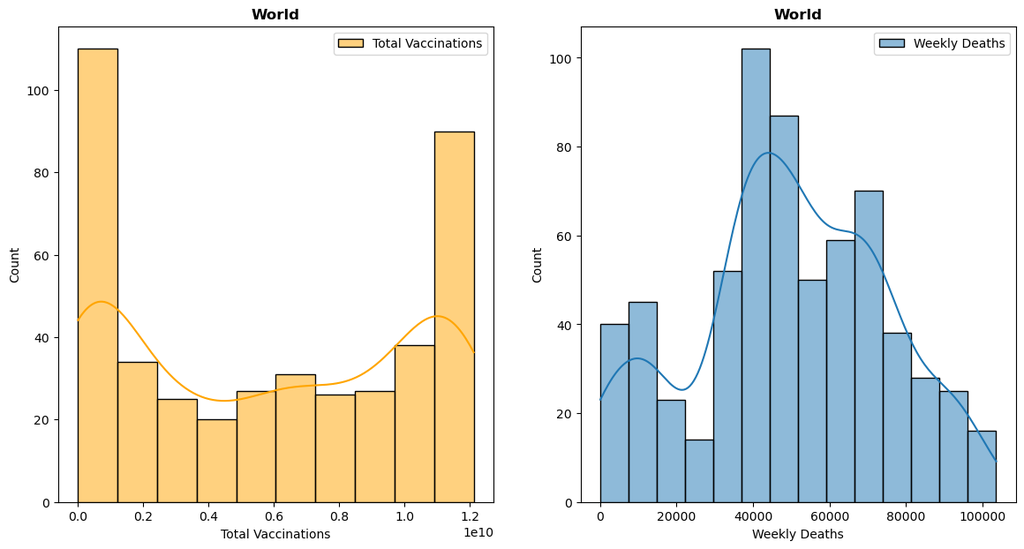

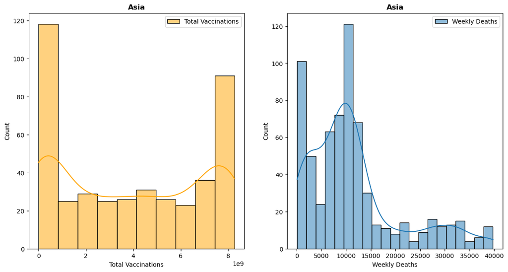

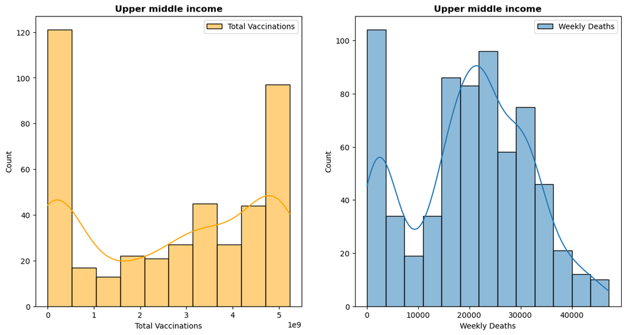

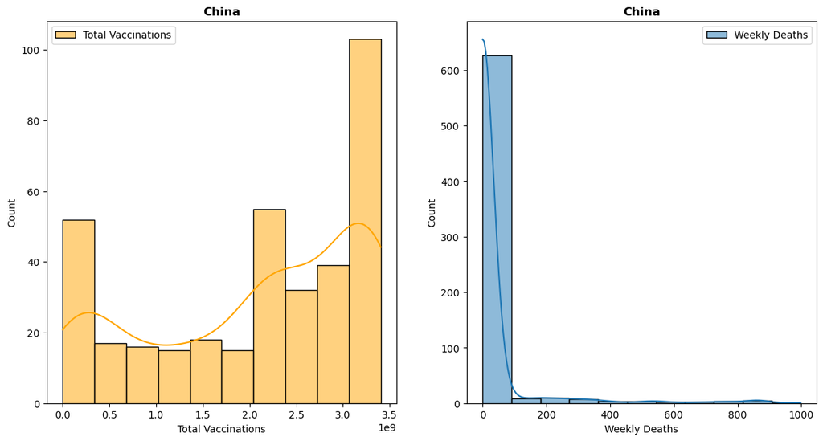

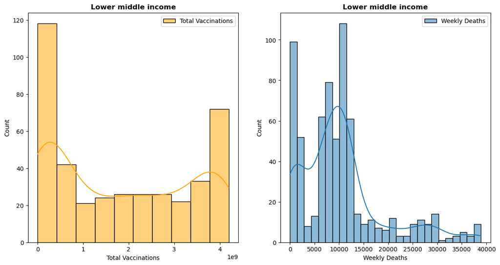

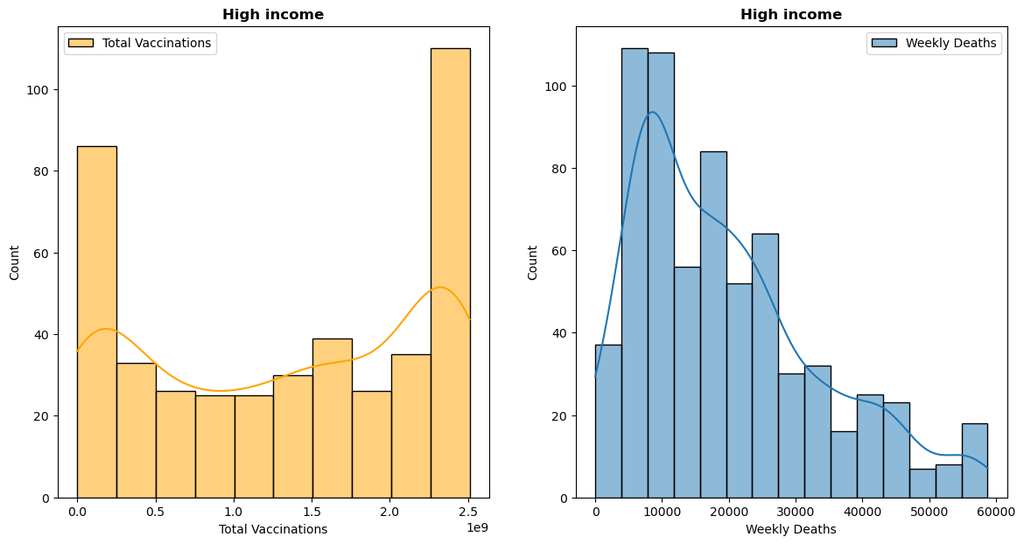

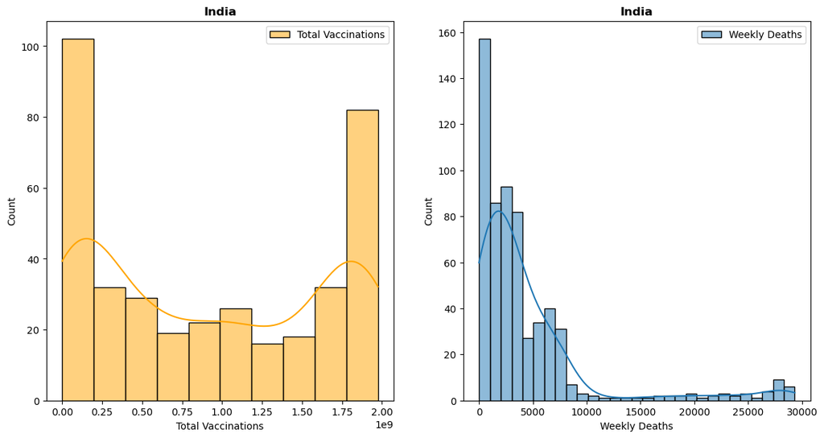

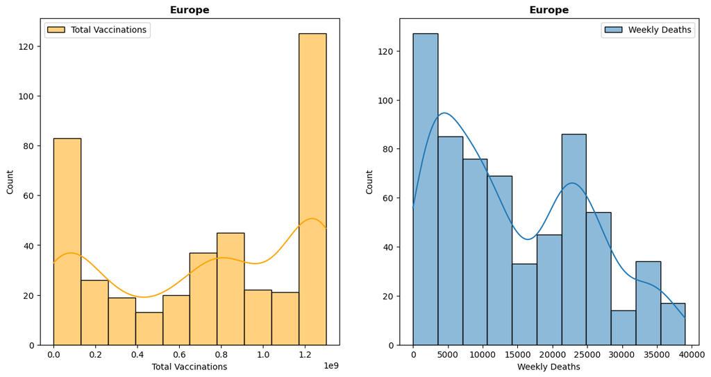

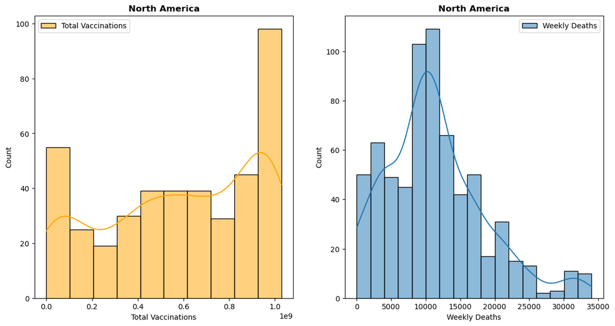

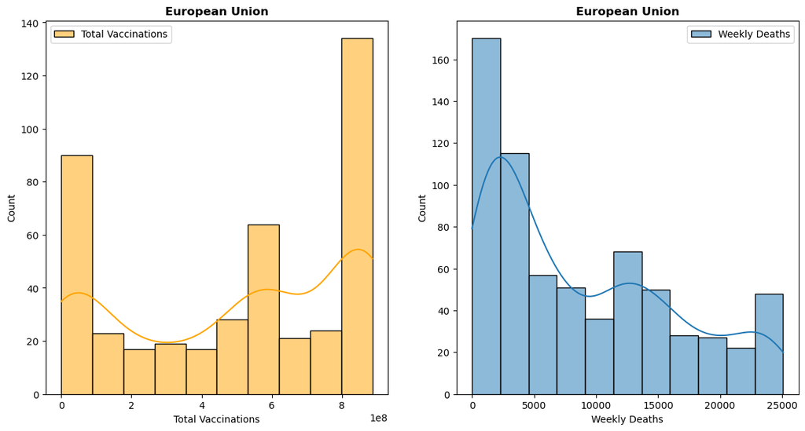

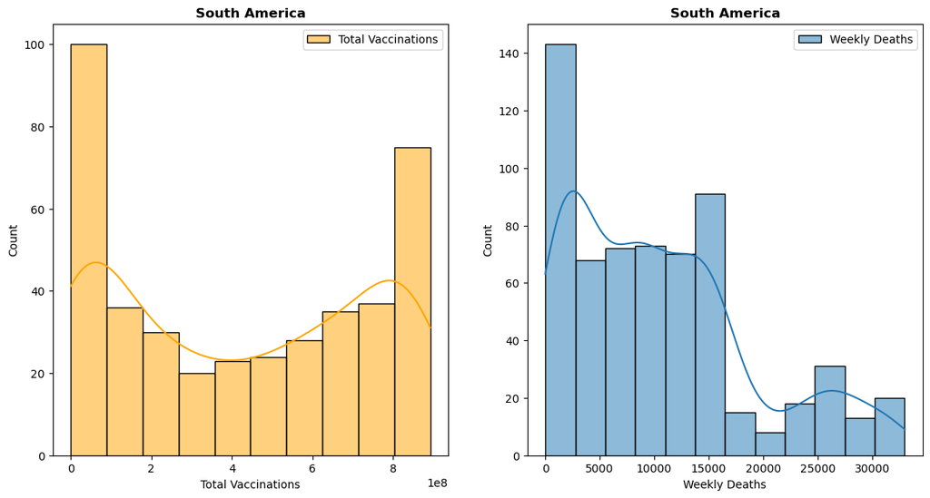

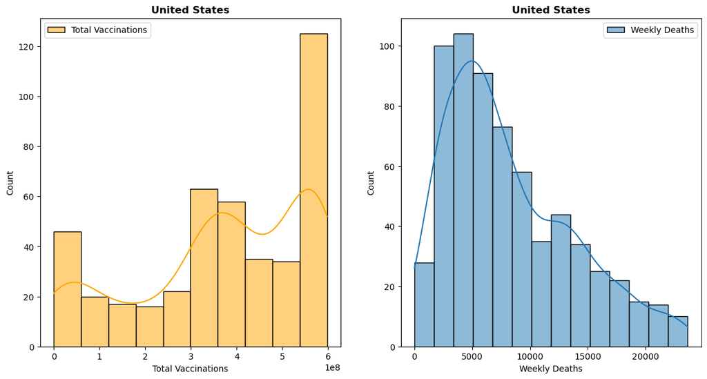

[4 more figures not shown]

```python
# Plot of the histograms of the 'Total Vaccinations' and 'Weekly Deaths' columns for the top 16 countries (or regions).
for location in data_grouped_top_index:
    plt.figure(figsize=(14,7))

    plt.subplot(1, 2, 1)
    sns.histplot(data_location_as_index["Total Vaccinations"][location], label='Total Vaccinations', kde=True, color='orange')
    plt.title(f'{location}', fontweight='bold')
    plt.legend()

    plt.subplot(1, 2, 2)
    sns.histplot(data_location_as_index["Weekly Deaths"][location], label='Weekly Deaths', kde=True)
    plt.title(f'{location}', fontweight='bold')
    plt.legend()


    plt.show()
```

**Here, the analysis also shows for some countries that:**

- The increase in **total vaccinations** does not directly correlate with a **significant reduction in weekly death numbers**. For example, this is the case between **Upper middle income (total vaccinations: 1.159670e+12, total weekly deaths: 13,535,982.0) and China (total vaccinations: 7.607777e+11, total weekly deaths: 20,054.0)**. **Upper middle income** has a higher total number of vaccinations than **China**, but at the same time, it has a **higher number of deaths than China**, which has a lower vaccination rate.

This is also the case with some other regions, such as **Europe and North America**, **South America and the United States**, **Japan and Brazil**, etc.

**NOTE: ONE CANNOT CONCLUDE FROM A FEW COUNTRIES THAT THE OVERALL INCREASE IN VACCINATION RATES DOES NOT LEAD TO A REDUCTION IN WEEKLY DEATHS. THE HYPOTHESIS TEST LATER WILL PROVIDE MORE INSIGHT.**

## I-III. Hypotheses to be tested:

- **Hypothesis 1: Do regions with higher vaccination rates have lower weekly death rates?**
  - **Formulation: Null hypothesis (H0): There is no significant monotonic relationship between vaccination rates and weekly deaths.**
- **Hypothesis 2: Do regions with higher COVID-19 case numbers have higher death rates?**
  - **Formulation: Null hypothesis (H0): There is no significant monotonic relationship between COVID-19 case numbers and weekly deaths or deaths in the following week(Next Week's Deaths)**
- **Hypothesis 3: Do regions with higher weekly death rates have higher death rates in the following week?**
  - **Formulation: Null hypothesis (H0): There is no significant monotonic relationship between weekly death rates and death rates in the following week.**

**ETC....**

#### Test preparation and test functions

```python
def hypo_preprocessing(data, column_names, year=2021, percentage=0.20):

    # Dictionaries for storing the prepared data
    top_laender_dict = {}
    down_laender_dict = {}
    top_down_laender_dict = {}

    for column_name in column_names:
        # Extraction of data for the specified year
        data_year = data[data['Year'] == year]

        # Calculation of the number of regions (percentage of regions)
        n = int(len(data_year["Location"].unique()) * percentage)

        # Top and bottom regions for the given column
        data_year_down = data_year.groupby("Location").sum().nsmallest(n, column_name)
        data_year_top = data_year.groupby("Location").sum().nlargest(n, column_name)

        # Extracting the rows for the top and bottom regions
        data_down = data.loc[(data["Location"].isin(data_year_down.index)) & (data["Year"] == year)]
        data_top = data.loc[(data["Location"].isin(data_year_top.index)) & (data["Year"] == year)]

        # Cleaning and creating a combined DataFrame
        data_down = data_down.dropna(axis=0, subset=["Weekly Cases", "Weekly Deaths", "Next Week's Deaths", column_name])
        data_top = data_top.dropna(axis=0, subset=["Weekly Cases", "Weekly Deaths", "Next Week's Deaths", column_name])
        data_top_down = pd.concat([data_down, data_top], ignore_index=True)

        #Balancing the two DataFrames
        if data_top.shape[0] > data_down.shape[0] :
            data_top = data_top.sample(data_down.shape[0])
        else :
            data_down = data_down.sample(data_top.shape[0])


        # storing in dictionaries
        top_laender_dict[column_name] = data_top
        down_laender_dict[column_name] = data_down
        top_down_laender_dict[column_name] = data_top_down

        print(f'\n\n***** {column_name.upper()} *****\n')
        print(f'data_top contains now : {data_top.shape[0]} lines et {data_top.shape[1]} columns')
        print(f'data_down contains now : {data_down.shape[0]} lines et {data_down.shape[1]} columns \n')
        print(f'TOP {len(data_year_top.index)} REGION WITH HIGHER NUMBER OF {column_name.upper()} IN {year}:\n\n{data_year_top.index}\n')
        print(f'BOTTOM {len(data_year_down.index)} REGION WITH HIGHER NUMBER OF {column_name.upper()} IN {year}:\n\n{data_year_down.index}')

    return top_laender_dict, down_laender_dict, top_down_laender_dict
```

```python
# Definition of T-Test function
from scipy.stats import ttest_ind

def ttest1(columns, hypothese_columns, groupe_1_dict, groupe_2_dict, year=2021):
    alpha = 0.05
    for hypo_col in hypothese_columns:
        print(f"\n\n NULL HYPOTHESIS (H0): THERE IS NO SIGNIFICANT DIFFERENCE IN THE MEAN OF THE VARIABLE BETWEEN THE GROUPS WITH HIGH AND LOW '{hypo_col.upper()}' ({year}) \n\n ")
        for col in columns:
            stat, p = ttest_ind(groupe_1_dict[hypo_col][col], groupe_2_dict[hypo_col][col])
            if p < alpha :
                print(f'{col :-<70} H0 REJECTED\n')
            else: print(f'{col :-<70} H0 RETAINED')
```

```python
# Definition of Spearman test function
from scipy.stats import ttest_ind

def spearmantest(columns, hypothese_columns, groupe_dict, year="totaldata"):
    alpha = 0.05
    for hypo_col in hypothese_columns:
        print(f"\n\n H0 HYPOTHESIS: THERE IS NO SIGNIFICANT MONOTONIC RELATIONSHIP BETWEEN '{hypo_col.upper()}' AND THE OTHER VARIABLES ({year}) \n\n ")
        for col in columns:
            if col != hypo_col:
                coef, p = spearmanr(groupe_dict[hypo_col][hypo_col], groupe_dict[hypo_col][col])
                if p < alpha:
                    print(f'{hypo_col} und {col :-<70} H0 REJECTED (coef={coef:.3f}, p={p:.3f})\n')
                else:
                    print(f' {hypo_col} und {col :-<70} H0 RETAINED (coef={coef:.3f}, p={p:.3f})\n')

        print("\n\n****************************************************************************************************")
```

#### Application of Tests to the 2020 data

```python
#Call of hypo_preprocessing for the 2020 data
column_names = ["Total Vaccinations", "Weekly Deaths", "Weekly Cases"]
data_top_dict_2020, data_down_dict_2020, data_top_down_dict_2020 = hypo_preprocessing(data, column_names, year=2020)

data_top_down_dict_2020['Weekly Deaths'].head()
```

```
***** TOTAL VACCINATIONS *****

data_top contains now : 2 lines et 20 columns
data_down contains now : 2 lines et 20 columns

TOP 40 REGION WITH HIGHER NUMBER OF TOTAL VACCINATIONS IN 2020:

Index(['High income', 'World', 'Asia', 'United States', 'Upper middle income',
       'North America', 'China', 'Israel', 'European Union', 'Europe',
       'Germany', 'Canada', 'Bahrain', 'South America', 'Russia', 'Denmark',
       'Italy', 'Mexico', 'Poland', 'Argentina', 'Slovenia', 'Lithuania',
       'Switzerland', 'Romania', 'Oman', 'Chile', 'Czechia', 'Estonia',
       'Norway', 'France', 'Latvia', 'Greece', 'Luxembourg', 'Kuwait',
       'Bulgaria', 'Ireland', 'Hungary', 'Belgium', 'Singapore',
       'Afghanistan'],
      dtype='object', name='Location')

BOTTOM 40 REGION WITH HIGHER NUMBER OF TOTAL VACCINATIONS IN 2020:

Index(['Afghanistan', 'Africa', 'Albania', 'Algeria', 'Andorra', 'Angola',
       'Antigua and Barbuda', 'Armenia', 'Aruba', 'Australia', 'Austria',
       'Azerbaijan', 'Bahamas', 'Bangladesh', 'Barbados', 'Belarus', 'Belize',
       'Benin', 'Bermuda', 'Bolivia', 'Bonaire Sint Eustatius and Saba',
       'Bosnia and Herzegovina', 'Botswana', 'Brazil',
       'British Virgin Islands', 'Brunei', 'Burkina Faso', 'Burundi',
       'Cameroon', 'Cape Verde', 'Cayman Islands', 'Central African Republic',
       'Chad', 'Colombia', 'Comoros', 'Congo', 'Costa Rica', 'Cote d'Ivoire',
       'Croatia', 'Cuba'],
      dtype='object', name='Location')


***** WEEKLY DEATHS *****

data_top contains now : 6837 lines et 20 columns
data_down contains now : 6837 lines et 20 columns

TOP 40 REGION WITH HIGHER NUMBER OF WEEKLY DEATHS IN 2020:

Index(['World', 'High income', 'Upper middle income', 'North America',
       'Europe', 'South America', 'European Union', 'United States', 'Asia',
```

[output cut: 37 more lines]

```
       'Philippines', 'Morocco', 'Switzerland'],
      dtype='object', name='Location')

BOTTOM 40 REGION WITH HIGHER NUMBER OF WEEKLY CASES IN 2020:

Index(['Montserrat', 'Fiji', 'Brunei', 'British Virgin Islands',
       'Antigua and Barbuda', 'Bonaire Sint Eustatius and Saba', 'Saint Lucia',
       'Mongolia', 'Eritrea', 'Cayman Islands', 'Barbados', 'International',
       'Isle of Man', 'Tanzania', 'Mauritius', 'Bermuda', 'Comoros',
       'Papua New Guinea', 'Burundi', 'Taiwan', 'Monaco',
       'Turks and Caicos Islands', 'Sao Tome and Principe', 'Vietnam',
       'Gibraltar', 'Liberia', 'New Zealand', 'Liechtenstein', 'Yemen',
       'San Marino', 'Chad', 'Guinea-Bissau', 'Sierra Leone', 'Lesotho',
       'Niger', 'South Sudan', 'Benin', 'Togo', 'Curacao', 'Gambia'],
      dtype='object', name='Location')
```

|  | Id | Location | Weekly Cases | Year | Weekly Cases per Million | Weekly Deaths | Weekly Deaths per Million | Total Vaccinations | People Vaccinated | People Fully Vaccinated | Total Boosters | Daily Vaccinations | Total Vaccinations per Hundred | People Vaccinated per Hundred | People Fully Vaccinated per Hundred | Total Boosters per Hundred | Daily Vaccinations per Hundred | Daily People Vaccinated | Daily People Vaccinated per Hundred | Next Week's Deaths |
| --- | --- | --- | --- | --- | --- | --- | --- | --- | --- | --- | --- | --- | --- | --- | --- | --- | --- | --- | --- | --- |
| 0 | 322402222 | Antigua and Barbuda | 6.0 | 2020 | 64.364 | 2.0 | 21.455 | NaN | NaN | NaN | NaN | NaN | NaN | NaN | NaN | NaN | NaN | NaN | NaN | 1.0 |
| 1 | 572578633 | Antigua and Barbuda | 8.0 | 2020 | 85.818 | 2.0 | 21.455 | NaN | NaN | NaN | NaN | NaN | NaN | NaN | NaN | NaN | NaN | NaN | NaN | 1.0 |
| 2 | 852095863 | Antigua and Barbuda | 4.0 | 2020 | 42.909 | 1.0 | 10.727 | NaN | NaN | NaN | NaN | NaN | NaN | NaN | NaN | NaN | NaN | NaN | NaN | 1.0 |
| 3 | 649506512 | Antigua and Barbuda | 4.0 | 2020 | 42.909 | 0.0 | 0.000 | NaN | NaN | NaN | NaN | NaN | NaN | NaN | NaN | NaN | NaN | NaN | NaN | 1.0 |
| 4 | 949219283 | Antigua and Barbuda | 4.0 | 2020 | 42.909 | 1.0 | 10.727 | NaN | NaN | NaN | NaN | NaN | NaN | NaN | NaN | NaN | NaN | NaN | NaN | 0.0 |

```python
#application of  T-Tests for 2020
ttest1(list(data.drop(["Id", "Location"], axis=1).columns), ["Total Vaccinations", "Weekly Deaths", "Weekly Cases"],
       data_top_dict_2020, data_down_dict_2020, year=2020)
```

```
 NULL HYPOTHESIS (H0): THERE IS NO SIGNIFICANT DIFFERENCE IN THE MEAN OF THE VARIABLE BETWEEN THE GROUPS WITH HIGH AND LOW 'TOTAL VACCINATIONS' (2020)


Weekly Cases---------------------------------------------------------- H0 RETAINED
Year------------------------------------------------------------------ H0 RETAINED
Weekly Cases per Million---------------------------------------------- H0 RETAINED
Weekly Deaths--------------------------------------------------------- H0 RETAINED
Weekly Deaths per Million--------------------------------------------- H0 RETAINED
Total Vaccinations---------------------------------------------------- H0 REJECTED

People Vaccinated----------------------------------------------------- H0 REJECTED

People Fully Vaccinated----------------------------------------------- H0 RETAINED
Total Boosters-------------------------------------------------------- H0 RETAINED
Daily Vaccinations---------------------------------------------------- H0 RETAINED
Total Vaccinations per Hundred---------------------------------------- H0 RETAINED
People Vaccinated per Hundred----------------------------------------- H0 RETAINED
People Fully Vaccinated per Hundred----------------------------------- H0 RETAINED
Total Boosters per Hundred-------------------------------------------- H0 RETAINED
Daily Vaccinations per Hundred---------------------------------------- H0 RETAINED
Daily People Vaccinated----------------------------------------------- H0 RETAINED
Daily People Vaccinated per Hundred----------------------------------- H0 RETAINED
Next Week's Deaths---------------------------------------------------- H0 RETAINED


 NULL HYPOTHESIS (H0): THERE IS NO SIGNIFICANT DIFFERENCE IN THE MEAN OF THE VARIABLE BETWEEN THE GROUPS WITH HIGH AND LOW 'WEEKLY DEATHS' (2020)


Weekly Cases---------------------------------------------------------- H0 REJECTED

Year------------------------------------------------------------------ H0 RETAINED
Weekly Cases per Million---------------------------------------------- H0 RETAINED
Weekly Deaths--------------------------------------------------------- H0 REJECTED

Weekly Deaths per Million--------------------------------------------- H0 RETAINED
Total Vaccinations---------------------------------------------------- H0 RETAINED
People Vaccinated----------------------------------------------------- H0 RETAINED
People Fully Vaccinated----------------------------------------------- H0 RETAINED
Total Boosters-------------------------------------------------------- H0 RETAINED
Daily Vaccinations---------------------------------------------------- H0 RETAINED
```

[output cut: 19 more lines]

```

Weekly Deaths per Million--------------------------------------------- H0 RETAINED
Total Vaccinations---------------------------------------------------- H0 RETAINED
People Vaccinated----------------------------------------------------- H0 RETAINED
People Fully Vaccinated----------------------------------------------- H0 RETAINED
Total Boosters-------------------------------------------------------- H0 RETAINED
Daily Vaccinations---------------------------------------------------- H0 RETAINED
Total Vaccinations per Hundred---------------------------------------- H0 RETAINED
People Vaccinated per Hundred----------------------------------------- H0 RETAINED
People Fully Vaccinated per Hundred----------------------------------- H0 RETAINED
Total Boosters per Hundred-------------------------------------------- H0 RETAINED
Daily Vaccinations per Hundred---------------------------------------- H0 RETAINED
Daily People Vaccinated----------------------------------------------- H0 RETAINED
Daily People Vaccinated per Hundred----------------------------------- H0 RETAINED
Next Week's Deaths---------------------------------------------------- H0 REJECTED
```

**FOR 2020:**

According to the **t-test**, there is a significant difference between countries with high and low weekly COVID-19 cases(Weekly Cases) concerning "**Weekly Deaths**" and "**Next Week's Deaths.**" This difference is not random. It suggests an association between weekly COVID-19 cases and these variables. However, this analysis alone does not allow a conclusion about a causal relationship. An increase in weekly COVID-19 cases may be associated with an increase in weekly deaths, but further analyses would be required to confirm a direct effect.**

```python
#Application of Spearmann-Tests for 2020,
from scipy.stats import spearmanr
spearmantest(list(data.drop(["Id", "Location"], axis=1).columns), ["Total Vaccinations", "Weekly Deaths", "Weekly Cases"],
       data_top_down_dict_2020, year="2020")
```

```
 H0 HYPOTHESIS: THERE IS NO SIGNIFICANT MONOTONIC RELATIONSHIP BETWEEN 'TOTAL VACCINATIONS' AND THE OTHER VARIABLES (2020)


Total Vaccinations und Weekly Cases---------------------------------------------------------- H0 REJECTED (coef=0.315, p=0.000)

 Total Vaccinations und Year------------------------------------------------------------------ H0 RETAINED (coef=nan, p=nan)

 Total Vaccinations und Weekly Cases per Million---------------------------------------------- H0 RETAINED (coef=-0.089, p=0.131)

Total Vaccinations und Weekly Deaths--------------------------------------------------------- H0 REJECTED (coef=0.250, p=0.000)

Total Vaccinations und Weekly Deaths per Million--------------------------------------------- H0 REJECTED (coef=-0.167, p=0.004)

 Total Vaccinations und People Vaccinated----------------------------------------------------- H0 RETAINED (coef=nan, p=nan)

 Total Vaccinations und People Fully Vaccinated----------------------------------------------- H0 RETAINED (coef=nan, p=nan)

 Total Vaccinations und Total Boosters-------------------------------------------------------- H0 RETAINED (coef=nan, p=nan)

 Total Vaccinations und Daily Vaccinations---------------------------------------------------- H0 RETAINED (coef=nan, p=nan)

Total Vaccinations und Total Vaccinations per Hundred---------------------------------------- H0 REJECTED (coef=0.757, p=0.000)

 Total Vaccinations und People Vaccinated per Hundred----------------------------------------- H0 RETAINED (coef=nan, p=nan)

 Total Vaccinations und People Fully Vaccinated per Hundred----------------------------------- H0 RETAINED (coef=nan, p=nan)

 Total Vaccinations und Total Boosters per Hundred-------------------------------------------- H0 RETAINED (coef=nan, p=nan)

 Total Vaccinations und Daily Vaccinations per Hundred---------------------------------------- H0 RETAINED (coef=nan, p=nan)

 Total Vaccinations und Daily People Vaccinated----------------------------------------------- H0 RETAINED (coef=nan, p=nan)

 Total Vaccinations und Daily People Vaccinated per Hundred----------------------------------- H0 RETAINED (coef=nan, p=nan)

Total Vaccinations und Next Week's Deaths---------------------------------------------------- H0 REJECTED (coef=0.239, p=0.000)




```

[output cut: 63 more lines]

```
 Weekly Cases und Total Vaccinations per Hundred---------------------------------------- H0 RETAINED (coef=nan, p=nan)

 Weekly Cases und People Vaccinated per Hundred----------------------------------------- H0 RETAINED (coef=nan, p=nan)

 Weekly Cases und People Fully Vaccinated per Hundred----------------------------------- H0 RETAINED (coef=nan, p=nan)

 Weekly Cases und Total Boosters per Hundred-------------------------------------------- H0 RETAINED (coef=nan, p=nan)

 Weekly Cases und Daily Vaccinations per Hundred---------------------------------------- H0 RETAINED (coef=nan, p=nan)

 Weekly Cases und Daily People Vaccinated----------------------------------------------- H0 RETAINED (coef=nan, p=nan)

 Weekly Cases und Daily People Vaccinated per Hundred----------------------------------- H0 RETAINED (coef=nan, p=nan)

Weekly Cases und Next Week's Deaths---------------------------------------------------- H0 REJECTED (coef=0.952, p=0.000)
```

**2020**

The **Spearman tests** show significant monotonic correlations between certain variables, particularly between **Total Vaccinations and Total Vaccinations per Hundred**; **weekly deaths and next week's deaths**. The strongest relationships are observed between **"Weekly Deaths und Next Week's Deaths" (coef = 0.974)**. However, other variables, such as those related to **vaccinated people and boosters**, do not show a significant monotonic relationship with the other data.

#### Application of tests to the 2021 data

```python
#Call of hypo_preprocessing for the 2021 data
column_names = ["Total Vaccinations", "Weekly Deaths", "Weekly Cases"]
data_top_dict_2021, data_down_dict_2021, data_top_down_dict_2021 = hypo_preprocessing(data, column_names, year=2021)

data_top_down_dict_2021['Weekly Deaths'].head()
```

```
***** TOTAL VACCINATIONS *****

data_top contains now : 1033 lines et 20 columns
data_down contains now : 1033 lines et 20 columns

TOP 43 REGION WITH HIGHER NUMBER OF TOTAL VACCINATIONS IN 2021:

Index(['World', 'Asia', 'Upper middle income', 'China', 'Lower middle income',
       'High income', 'Europe', 'India', 'North America', 'European Union',
       'United States', 'South America', 'Brazil', 'Indonesia', 'Japan',
       'Africa', 'Germany', 'United Kingdom', 'Turkey', 'France', 'Russia',
       'Italy', 'Mexico', 'Canada', 'South Korea', 'Argentina', 'Spain',
       'Thailand', 'Vietnam', 'Saudi Arabia', 'Chile', 'Malaysia', 'Poland',
       'Pakistan', 'Oceania', 'Colombia', 'Philippines', 'Bangladesh', 'Peru',
       'Low income', 'Australia', 'Cambodia', 'Sri Lanka'],
      dtype='object', name='Location')

BOTTOM 43 REGION WITH HIGHER NUMBER OF TOTAL VACCINATIONS IN 2021:

Index(['Eritrea', 'International', 'Bonaire Sint Eustatius and Saba',
       'Burundi', 'Montserrat', 'Greenland', 'Anguilla', 'Wallis and Futuna',
       'Djibouti', 'Turks and Caicos Islands', 'British Virgin Islands',
       'Monaco', 'Dominica', 'Vanuatu', 'Andorra', 'Saint Kitts and Nevis',
       'Sao Tome and Principe', 'Grenada', 'Saint Vincent and the Grenadines',
       'Central African Republic', 'Bermuda', 'Haiti', 'Papua New Guinea',
       'Yemen', 'San Marino', 'New Caledonia', 'South Sudan', 'Burkina Faso',
       'Sierra Leone', 'Gambia', 'Lesotho', 'Liberia', 'Gabon', 'Chad',
       'Democratic Republic of Congo', 'Comoros', 'Guinea-Bissau', 'Bahamas',
       'Antigua and Barbuda', 'Faeroe Islands', 'Madagascar',
       'French Polynesia', 'Tanzania'],
      dtype='object', name='Location')


***** WEEKLY DEATHS *****

data_top contains now : 10703 lines et 20 columns
data_down contains now : 10703 lines et 20 columns

TOP 43 REGION WITH HIGHER NUMBER OF WEEKLY DEATHS IN 2021:

```

[output cut: 43 more lines]

```

BOTTOM 43 REGION WITH HIGHER NUMBER OF WEEKLY CASES IN 2021:

Index(['International', 'Vanuatu', 'Montserrat', 'Wallis and Futuna',
       'Greenland', 'Anguilla', 'Bhutan', 'Turks and Caicos Islands',
       'Sao Tome and Principe', 'British Virgin Islands',
       'Saint Kitts and Nevis', 'Bonaire Sint Eustatius and Saba', 'Hong Kong',
       'Guinea-Bissau', 'Liechtenstein', 'Chad', 'Antigua and Barbuda',
       'Monaco', 'Tajikistan', 'Sierra Leone', 'Liberia', 'Niger', 'Bermuda',
       'Comoros', 'Faeroe Islands', 'San Marino',
       'Saint Vincent and the Grenadines', 'Dominica',
       'Central African Republic', 'Gambia', 'Grenada', 'Eritrea', 'Gibraltar',
       'Djibouti', 'Yemen', 'Equatorial Guinea', 'Nicaragua', 'Cayman Islands',
       'Burkina Faso', 'New Zealand', 'South Sudan', 'New Caledonia', 'Mali'],
      dtype='object', name='Location')
```

|  | Id | Location | Weekly Cases | Year | Weekly Cases per Million | Weekly Deaths | Weekly Deaths per Million | Total Vaccinations | People Vaccinated | People Fully Vaccinated | Total Boosters | Daily Vaccinations | Total Vaccinations per Hundred | People Vaccinated per Hundred | People Fully Vaccinated per Hundred | Total Boosters per Hundred | Daily Vaccinations per Hundred | Daily People Vaccinated | Daily People Vaccinated per Hundred | Next Week's Deaths |
| --- | --- | --- | --- | --- | --- | --- | --- | --- | --- | --- | --- | --- | --- | --- | --- | --- | --- | --- | --- | --- |
| 0 | 955039050 | Andorra | 361.0 | 2021 | 4567.654 | 1.0 | 12.653 | NaN | NaN | NaN | NaN | NaN | NaN | NaN | NaN | NaN | NaN | NaN | NaN | 0.0 |
| 1 | 193148502 | Andorra | 360.0 | 2021 | 4555.002 | 1.0 | 12.653 | NaN | NaN | NaN | NaN | NaN | NaN | NaN | NaN | NaN | NaN | NaN | NaN | 1.0 |
| 2 | 363805587 | Andorra | 371.0 | 2021 | 4694.182 | 1.0 | 12.653 | NaN | NaN | NaN | NaN | NaN | NaN | NaN | NaN | NaN | NaN | NaN | NaN | 1.0 |
| 3 | 210086497 | Andorra | 389.0 | 2021 | 4921.932 | 0.0 | 0.000 | NaN | NaN | NaN | NaN | NaN | NaN | NaN | NaN | NaN | NaN | NaN | NaN | 2.0 |
| 4 | 733229232 | Andorra | 365.0 | 2021 | 4618.266 | 0.0 | 0.000 | NaN | NaN | NaN | NaN | NaN | NaN | NaN | NaN | NaN | NaN | NaN | NaN | 3.0 |

```python
#Application of T-Tests for 2021
ttest1(list(data.drop(["Id", "Location"], axis=1).columns), ["Total Vaccinations", "Weekly Deaths", "Weekly Cases"],
       data_top_dict_2021, data_down_dict_2021, year=2021)
```

```
 NULL HYPOTHESIS (H0): THERE IS NO SIGNIFICANT DIFFERENCE IN THE MEAN OF THE VARIABLE BETWEEN THE GROUPS WITH HIGH AND LOW 'TOTAL VACCINATIONS' (2021)


Weekly Cases---------------------------------------------------------- H0 REJECTED

Year------------------------------------------------------------------ H0 RETAINED
Weekly Cases per Million---------------------------------------------- H0 RETAINED
Weekly Deaths--------------------------------------------------------- H0 REJECTED

Weekly Deaths per Million--------------------------------------------- H0 RETAINED
Total Vaccinations---------------------------------------------------- H0 REJECTED

People Vaccinated----------------------------------------------------- H0 RETAINED
People Fully Vaccinated----------------------------------------------- H0 RETAINED
Total Boosters-------------------------------------------------------- H0 RETAINED
Daily Vaccinations---------------------------------------------------- H0 RETAINED
Total Vaccinations per Hundred---------------------------------------- H0 REJECTED

People Vaccinated per Hundred----------------------------------------- H0 RETAINED
People Fully Vaccinated per Hundred----------------------------------- H0 RETAINED
Total Boosters per Hundred-------------------------------------------- H0 RETAINED
Daily Vaccinations per Hundred---------------------------------------- H0 RETAINED
Daily People Vaccinated----------------------------------------------- H0 RETAINED
Daily People Vaccinated per Hundred----------------------------------- H0 RETAINED
Next Week's Deaths---------------------------------------------------- H0 REJECTED



 NULL HYPOTHESIS (H0): THERE IS NO SIGNIFICANT DIFFERENCE IN THE MEAN OF THE VARIABLE BETWEEN THE GROUPS WITH HIGH AND LOW 'WEEKLY DEATHS' (2021)


Weekly Cases---------------------------------------------------------- H0 REJECTED

Year------------------------------------------------------------------ H0 RETAINED
Weekly Cases per Million---------------------------------------------- H0 RETAINED
Weekly Deaths--------------------------------------------------------- H0 REJECTED

Weekly Deaths per Million--------------------------------------------- H0 RETAINED
Total Vaccinations---------------------------------------------------- H0 RETAINED
People Vaccinated----------------------------------------------------- H0 RETAINED
```

[output cut: 22 more lines]

```

Weekly Deaths per Million--------------------------------------------- H0 RETAINED
Total Vaccinations---------------------------------------------------- H0 RETAINED
People Vaccinated----------------------------------------------------- H0 RETAINED
People Fully Vaccinated----------------------------------------------- H0 RETAINED
Total Boosters-------------------------------------------------------- H0 RETAINED
Daily Vaccinations---------------------------------------------------- H0 RETAINED
Total Vaccinations per Hundred---------------------------------------- H0 RETAINED
People Vaccinated per Hundred----------------------------------------- H0 RETAINED
People Fully Vaccinated per Hundred----------------------------------- H0 RETAINED
Total Boosters per Hundred-------------------------------------------- H0 RETAINED
Daily Vaccinations per Hundred---------------------------------------- H0 RETAINED
Daily People Vaccinated----------------------------------------------- H0 RETAINED
Daily People Vaccinated per Hundred----------------------------------- H0 RETAINED
Next Week's Deaths---------------------------------------------------- H0 REJECTED
```

**2021 :**

According to the **t-test**, there is a **significant difference between countries with high and low vaccination rates** concerning "**weekly cases**," "**weekly deaths**," "**total vaccinations per hundred**," and "**next week's deaths**." This difference is not random. It suggests an association between the vaccination rate and these variables. However, this analysis alone does not allow for a conclusion about a causal relationship. An increase in the vaccination rate may be associated with a reduction in weekly deaths, but further analyses would be needed to confirm a direct effect.

```python
#Application of Spearmann-Tests for 2021,
from scipy.stats import spearmanr
spearmantest(list(data.drop(["Id", "Location"], axis=1).columns), ["Total Vaccinations", "Weekly Deaths", "Weekly Cases"],
       data_top_down_dict_2021, year="2021")
```

```
 H0 HYPOTHESIS: THERE IS NO SIGNIFICANT MONOTONIC RELATIONSHIP BETWEEN 'TOTAL VACCINATIONS' AND THE OTHER VARIABLES (2021)


Total Vaccinations und Weekly Cases---------------------------------------------------------- H0 REJECTED (coef=0.612, p=0.000)

 Total Vaccinations und Year------------------------------------------------------------------ H0 RETAINED (coef=nan, p=nan)

Total Vaccinations und Weekly Cases per Million---------------------------------------------- H0 REJECTED (coef=0.131, p=0.000)

Total Vaccinations und Weekly Deaths--------------------------------------------------------- H0 REJECTED (coef=0.543, p=0.000)

Total Vaccinations und Weekly Deaths per Million--------------------------------------------- H0 REJECTED (coef=0.128, p=0.000)

 Total Vaccinations und People Vaccinated----------------------------------------------------- H0 RETAINED (coef=nan, p=nan)

 Total Vaccinations und People Fully Vaccinated----------------------------------------------- H0 RETAINED (coef=nan, p=nan)

 Total Vaccinations und Total Boosters-------------------------------------------------------- H0 RETAINED (coef=nan, p=nan)

 Total Vaccinations und Daily Vaccinations---------------------------------------------------- H0 RETAINED (coef=nan, p=nan)

Total Vaccinations und Total Vaccinations per Hundred---------------------------------------- H0 REJECTED (coef=0.561, p=0.000)

 Total Vaccinations und People Vaccinated per Hundred----------------------------------------- H0 RETAINED (coef=nan, p=nan)

 Total Vaccinations und People Fully Vaccinated per Hundred----------------------------------- H0 RETAINED (coef=nan, p=nan)

 Total Vaccinations und Total Boosters per Hundred-------------------------------------------- H0 RETAINED (coef=nan, p=nan)

 Total Vaccinations und Daily Vaccinations per Hundred---------------------------------------- H0 RETAINED (coef=nan, p=nan)

 Total Vaccinations und Daily People Vaccinated----------------------------------------------- H0 RETAINED (coef=nan, p=nan)

 Total Vaccinations und Daily People Vaccinated per Hundred----------------------------------- H0 RETAINED (coef=nan, p=nan)

Total Vaccinations und Next Week's Deaths---------------------------------------------------- H0 REJECTED (coef=0.540, p=0.000)




```

[output cut: 63 more lines]

```
 Weekly Cases und Total Vaccinations per Hundred---------------------------------------- H0 RETAINED (coef=nan, p=nan)

 Weekly Cases und People Vaccinated per Hundred----------------------------------------- H0 RETAINED (coef=nan, p=nan)

 Weekly Cases und People Fully Vaccinated per Hundred----------------------------------- H0 RETAINED (coef=nan, p=nan)

 Weekly Cases und Total Boosters per Hundred-------------------------------------------- H0 RETAINED (coef=nan, p=nan)

 Weekly Cases und Daily Vaccinations per Hundred---------------------------------------- H0 RETAINED (coef=nan, p=nan)

 Weekly Cases und Daily People Vaccinated----------------------------------------------- H0 RETAINED (coef=nan, p=nan)

 Weekly Cases und Daily People Vaccinated per Hundred----------------------------------- H0 RETAINED (coef=nan, p=nan)

Weekly Cases und Next Week's Deaths---------------------------------------------------- H0 REJECTED (coef=0.944, p=0.000)
```

**2021**

#### Application of tests to the 2022 Data

```python
#Call of hypo_preprocessing for the 2022 data
column_names = ["Total Vaccinations", "Weekly Deaths", "Weekly Cases"]
data_top_dict_2022, data_down_dict_2022, data_top_down_dict_2022 = hypo_preprocessing(data, column_names, year=2022)

data_top_down_dict_2022['Weekly Deaths'].head()
```

```
***** TOTAL VACCINATIONS *****

data_top contains now : 439 lines et 20 columns
data_down contains now : 439 lines et 20 columns

TOP 44 REGION WITH HIGHER NUMBER OF TOTAL VACCINATIONS IN 2022:

Index(['World', 'Asia', 'Upper middle income', 'Lower middle income', 'China',
       'High income', 'India', 'Europe', 'North America', 'European Union',
       'South America', 'United States', 'Africa', 'Brazil', 'Japan',
       'Indonesia', 'Germany', 'France', 'United Kingdom', 'Low income',
       'Vietnam', 'Pakistan', 'Italy', 'Thailand', 'Turkey', 'South Korea',
       'Russia', 'Bangladesh', 'Argentina', 'Mexico', 'Canada', 'Iran',
       'Oceania', 'Peru', 'Malaysia', 'Chile', 'Australia', 'Poland', 'Taiwan',
       'Philippines', 'Cuba', 'Ecuador', 'Colombia', 'Spain'],
      dtype='object', name='Location')

BOTTOM 44 REGION WITH HIGHER NUMBER OF TOTAL VACCINATIONS IN 2022:

Index(['Bonaire Sint Eustatius and Saba', 'Cook Islands', 'Eritrea',
       'International', 'Monaco', 'North Korea', 'Palau',
       'Saint Pierre and Miquelon', 'Montserrat', 'Burundi',
       'Wallis and Futuna', 'Turks and Caicos Islands', 'Anguilla',
       'Saint Kitts and Nevis', 'British Virgin Islands', 'Kiribati',
       'Greenland', 'Sao Tome and Principe', 'Vanuatu', 'Tonga', 'San Marino',
       'Antigua and Barbuda', 'Lesotho', 'Faeroe Islands', 'Macao', 'Bermuda',
       'Andorra', 'Cayman Islands', 'Bosnia and Herzegovina', 'Dominica',
       'Djibouti', 'Grenada', 'Gambia', 'Seychelles',
       'Saint Vincent and the Grenadines', 'Comoros', 'Samoa', 'Bahamas',
       'Liechtenstein', 'Equatorial Guinea', 'Solomon Islands', 'Saint Lucia',
       'Namibia', 'Haiti'],
      dtype='object', name='Location')


***** WEEKLY DEATHS *****

data_top contains now : 5527 lines et 20 columns
data_down contains now : 5527 lines et 20 columns

TOP 44 REGION WITH HIGHER NUMBER OF WEEKLY DEATHS IN 2022:
```

[output cut: 45 more lines]

```

BOTTOM 44 REGION WITH HIGHER NUMBER OF WEEKLY CASES IN 2022:

Index(['International', 'Wallis and Futuna', 'North Korea', 'Macao',
       'Tajikistan', 'Sierra Leone', 'Montserrat', 'Nicaragua', 'Liberia',
       'Yemen', 'Niger', 'Chad', 'Eritrea', 'Guinea-Bissau', 'Cook Islands',
       'Anguilla', 'Sao Tome and Principe', 'Benin', 'Djibouti', 'Gambia',
       'Saint Pierre and Miquelon', 'Comoros', 'South Sudan', 'Kiribati',
       'Central African Republic', 'Palau', 'Turks and Caicos Islands',
       'Timor', 'Saint Kitts and Nevis', 'Equatorial Guinea', 'Somalia',
       'Congo', 'British Virgin Islands', 'Burkina Faso',
       'Saint Vincent and the Grenadines', 'Antigua and Barbuda', 'Guinea',
       'Syria', 'Bonaire Sint Eustatius and Saba', 'Haiti', 'Lesotho', 'Togo',
       'Eswatini', 'Dominica'],
      dtype='object', name='Location')
```

|  | Id | Location | Weekly Cases | Year | Weekly Cases per Million | Weekly Deaths | Weekly Deaths per Million | Total Vaccinations | People Vaccinated | People Fully Vaccinated | Total Boosters | Daily Vaccinations | Total Vaccinations per Hundred | People Vaccinated per Hundred | People Fully Vaccinated per Hundred | Total Boosters per Hundred | Daily Vaccinations per Hundred | Daily People Vaccinated | Daily People Vaccinated per Hundred | Next Week's Deaths |
| --- | --- | --- | --- | --- | --- | --- | --- | --- | --- | --- | --- | --- | --- | --- | --- | --- | --- | --- | --- | --- |
| 0 | 984724956 | Andorra | 2010.0 | 2022 | 25432.093 | 1.0 | 12.653 | NaN | NaN | NaN | NaN | 758.0 | NaN | NaN | NaN | NaN | 9591.0 | 27.0 | 0.034 | 1.0 |
| 1 | 888965535 | Andorra | 2170.0 | 2022 | 27456.538 | 1.0 | 12.653 | NaN | NaN | NaN | NaN | 865.0 | NaN | NaN | NaN | NaN | 10945.0 | 27.0 | 0.034 | 1.0 |
| 2 | 240962892 | Andorra | 2466.0 | 2022 | 31201.761 | 1.0 | 12.653 | NaN | NaN | NaN | NaN | 865.0 | NaN | NaN | NaN | NaN | 10945.0 | 27.0 | 0.034 | 0.0 |
| 3 | 253613407 | Andorra | 2167.0 | 2022 | 27418.579 | 1.0 | 12.653 | NaN | NaN | NaN | NaN | 865.0 | NaN | NaN | NaN | NaN | 10945.0 | 27.0 | 0.034 | 0.0 |
| 4 | 263432761 | Andorra | 2668.0 | 2022 | 33757.623 | 1.0 | 12.653 | NaN | NaN | NaN | NaN | 865.0 | NaN | NaN | NaN | NaN | 10945.0 | 27.0 | 0.034 | 1.0 |

```python
#Application of T-Tests for 2022
ttest1(list(data.drop(["Id", "Location"], axis=1).columns), ["Total Vaccinations", "Weekly Deaths", "Weekly Cases"],
       data_top_dict_2022, data_down_dict_2022, year=2022)
```

```
 NULL HYPOTHESIS (H0): THERE IS NO SIGNIFICANT DIFFERENCE IN THE MEAN OF THE VARIABLE BETWEEN THE GROUPS WITH HIGH AND LOW 'TOTAL VACCINATIONS' (2022)


Weekly Cases---------------------------------------------------------- H0 REJECTED

Year------------------------------------------------------------------ H0 RETAINED
Weekly Cases per Million---------------------------------------------- H0 REJECTED

Weekly Deaths--------------------------------------------------------- H0 REJECTED

Weekly Deaths per Million--------------------------------------------- H0 REJECTED

Total Vaccinations---------------------------------------------------- H0 REJECTED

People Vaccinated----------------------------------------------------- H0 RETAINED
People Fully Vaccinated----------------------------------------------- H0 RETAINED
Total Boosters-------------------------------------------------------- H0 RETAINED
Daily Vaccinations---------------------------------------------------- H0 REJECTED

Total Vaccinations per Hundred---------------------------------------- H0 REJECTED

People Vaccinated per Hundred----------------------------------------- H0 RETAINED
People Fully Vaccinated per Hundred----------------------------------- H0 RETAINED
Total Boosters per Hundred-------------------------------------------- H0 RETAINED
Daily Vaccinations per Hundred---------------------------------------- H0 REJECTED

Daily People Vaccinated----------------------------------------------- H0 RETAINED
Daily People Vaccinated per Hundred----------------------------------- H0 RETAINED
Next Week's Deaths---------------------------------------------------- H0 REJECTED



 NULL HYPOTHESIS (H0): THERE IS NO SIGNIFICANT DIFFERENCE IN THE MEAN OF THE VARIABLE BETWEEN THE GROUPS WITH HIGH AND LOW 'WEEKLY DEATHS' (2022)


Weekly Cases---------------------------------------------------------- H0 REJECTED

Year------------------------------------------------------------------ H0 RETAINED
Weekly Cases per Million---------------------------------------------- H0 RETAINED
Weekly Deaths--------------------------------------------------------- H0 REJECTED
```

[output cut: 26 more lines]

```

Weekly Deaths per Million--------------------------------------------- H0 RETAINED
Total Vaccinations---------------------------------------------------- H0 RETAINED
People Vaccinated----------------------------------------------------- H0 RETAINED
People Fully Vaccinated----------------------------------------------- H0 RETAINED
Total Boosters-------------------------------------------------------- H0 RETAINED
Daily Vaccinations---------------------------------------------------- H0 RETAINED
Total Vaccinations per Hundred---------------------------------------- H0 RETAINED
People Vaccinated per Hundred----------------------------------------- H0 RETAINED
People Fully Vaccinated per Hundred----------------------------------- H0 RETAINED
Total Boosters per Hundred-------------------------------------------- H0 RETAINED
Daily Vaccinations per Hundred---------------------------------------- H0 RETAINED
Daily People Vaccinated----------------------------------------------- H0 RETAINED
Daily People Vaccinated per Hundred----------------------------------- H0 RETAINED
Next Week's Deaths---------------------------------------------------- H0 REJECTED
```

```python
#Application of Spearmann-Tests for 2022,
from scipy.stats import spearmanr
spearmantest(list(data.drop(["Id", "Location"], axis=1).columns), ["Total Vaccinations", "Weekly Deaths", "Weekly Cases"],
       data_top_down_dict_2022, year="2022")
```

```
 H0 HYPOTHESIS: THERE IS NO SIGNIFICANT MONOTONIC RELATIONSHIP BETWEEN 'TOTAL VACCINATIONS' AND THE OTHER VARIABLES (2022)


Total Vaccinations und Weekly Cases---------------------------------------------------------- H0 REJECTED (coef=0.603, p=0.000)

 Total Vaccinations und Year------------------------------------------------------------------ H0 RETAINED (coef=nan, p=nan)

Total Vaccinations und Weekly Cases per Million---------------------------------------------- H0 REJECTED (coef=-0.168, p=0.000)

Total Vaccinations und Weekly Deaths--------------------------------------------------------- H0 REJECTED (coef=0.648, p=0.000)

Total Vaccinations und Weekly Deaths per Million--------------------------------------------- H0 REJECTED (coef=-0.071, p=0.000)

 Total Vaccinations und People Vaccinated----------------------------------------------------- H0 RETAINED (coef=nan, p=nan)

 Total Vaccinations und People Fully Vaccinated----------------------------------------------- H0 RETAINED (coef=nan, p=nan)

 Total Vaccinations und Total Boosters-------------------------------------------------------- H0 RETAINED (coef=nan, p=nan)

Total Vaccinations und Daily Vaccinations---------------------------------------------------- H0 REJECTED (coef=0.828, p=0.000)

Total Vaccinations und Total Vaccinations per Hundred---------------------------------------- H0 REJECTED (coef=-0.156, p=0.000)

 Total Vaccinations und People Vaccinated per Hundred----------------------------------------- H0 RETAINED (coef=nan, p=nan)

 Total Vaccinations und People Fully Vaccinated per Hundred----------------------------------- H0 RETAINED (coef=nan, p=nan)

 Total Vaccinations und Total Boosters per Hundred-------------------------------------------- H0 RETAINED (coef=nan, p=nan)

 Total Vaccinations und Daily Vaccinations per Hundred---------------------------------------- H0 RETAINED (coef=-0.020, p=0.130)

 Total Vaccinations und Daily People Vaccinated----------------------------------------------- H0 RETAINED (coef=nan, p=nan)

 Total Vaccinations und Daily People Vaccinated per Hundred----------------------------------- H0 RETAINED (coef=nan, p=nan)

Total Vaccinations und Next Week's Deaths---------------------------------------------------- H0 REJECTED (coef=0.640, p=0.000)




```

[output cut: 63 more lines]

```
 Weekly Cases und Total Vaccinations per Hundred---------------------------------------- H0 RETAINED (coef=nan, p=nan)

 Weekly Cases und People Vaccinated per Hundred----------------------------------------- H0 RETAINED (coef=nan, p=nan)

 Weekly Cases und People Fully Vaccinated per Hundred----------------------------------- H0 RETAINED (coef=nan, p=nan)

 Weekly Cases und Total Boosters per Hundred-------------------------------------------- H0 RETAINED (coef=nan, p=nan)

 Weekly Cases und Daily Vaccinations per Hundred---------------------------------------- H0 RETAINED (coef=nan, p=nan)

 Weekly Cases und Daily People Vaccinated----------------------------------------------- H0 RETAINED (coef=nan, p=nan)

 Weekly Cases und Daily People Vaccinated per Hundred----------------------------------- H0 RETAINED (coef=nan, p=nan)

Weekly Cases und Next Week's Deaths---------------------------------------------------- H0 REJECTED (coef=0.923, p=0.000)
```